## Make School Summer Academy NPS Project :)

# Data Cleaning

```python
df
```

|  | ID | Location | Track | Week | Rating (Num) | Schedule Pacing |
| --- | --- | --- | --- | --- | --- | --- |
| 0 | 134 | San Francisco | Apps, Explorer | Week 1 | 3 | Just right |
| 1 | 36 | Los Angeles | Apps | Week 1 | 4 | A little too fast |
| 2 | 117 | San Francisco | Games | Week 1 | 4 | Way too slow |
| 3 | 253 | NaN | NaN | Week 2 | 4 | A little too fast |
| 4 | 350 | New York City | Apps, Explorer | Week 1 | 4 | Just right |
| 5 | 23 | Redwood City | Apps | Week 1 | 5 | Just right |
| 6 | 28 | Los Angeles | Apps | Week 7 | 5 | Just right |
| 7 | 65 | San Francisco | Apps | Week 1 | 5 | A little too slow |
| 8 | 101 | Santa Clara | Apps | Week 1 | 5 | A little too slow |
| 9 | 124 | Santa Clara | Apps | Week 1 | 5 | Just right |
| 10 | 157 | Redwood City | Apps | Week 2 | 5 | Just right |
| 11 | 170 | Oakland | Apps | Week 2 | 5 | Just right |
| 12 | 255 | San Francisco | Apps | Week 2 | 5 | Way too fast |
| 13 | 289 | Washington DC | Apps | Week 1 | 5 | Just right |
| 14 | 299 | Washington DC | Apps, Explorer | Week 1 | 5 | A little too slow |
| 15 | 307 | NaN | NaN | Week 3 | 5 | A little too slow |
| 16 | 319 | Redwood City | Apps | Week 3 | 5 | Just right |
| 17 | 336 | New York City | Apps | Week 1 | 5 | A little too slow |
| 18 | 441 | San Francisco | Apps, Explorer | Week 3 | 5 | Just right |
| 19 | 482 | Santa Clara | Apps | Week 3 | 5 | Just right |
| 20 | 37 | Los Angeles | Games | Week 1 | 6 | Just right |
| 21 | 41 | Chicago | Apps, Explorer | Week 1 | 6 | Just right |
| 22 | 45 | Chicago | Apps | Week 1 | 6 | A little too slow |
| 23 | 47 | Chicago | Apps | Week 1 | 6 | A little too slow |
| 24 | 77 | San Francisco | Apps | Week 1 | 6 | A little too fast |
| 25 | 78 | San Francisco | Apps | Week 1 | 6 | A little too fast |
| 26 | 94 | San Francisco | Apps, Explorer | Week 1 | 6 | Just right |
| 27 | 193 | Santa Clara | Apps | Week 2 | 6 | Just right |
| 28 | 251 | San Francisco | Apps, Explorer | Week 2 | 6 | Just right |
| 29 | 254 | San Francisco | Apps | Week 2 | 6 | Way too fast |
| ... | ... | ... | ... | ... | ... | ... |
| 1423 | 1470 | New York City | Games | Week 7 | 10 | Just right |
| 1424 | 1471 | New York City | Apps | Week 7 | 8 | Just right |
| 1425 | 1472 | New York City | Games | Week 7 | 9 | Just right |
| 1426 | 1473 | New York City | Games, Explorer | Week 7 | 10 | Just right |
| 1427 | 1474 | New York City | Games | Week 7 | 9 | Just right |
| 1428 | 1475 | New York City | Apps | Week 7 | 9 | Just right |
| 1429 | 1476 | New York City | Apps | Week 7 | 8 | A little too fast |
| 1430 | 1477 | New York City | Games | Week 7 | 10 | Just right |
| 1431 | 1478 | New York City | Apps | Week 7 | 10 | Just right |
| 1432 | 1479 | New York City | Games | Week 7 | 9 | Just right |
| 1433 | 1480 | New York City | Apps | Week 7 | 9 | Just right |
| 1434 | 1481 | New York City | Apps | Week 7 | 10 | Just right |
| 1435 | 1482 | New York City | Apps | Week 7 | 8 | Just right |
| 1436 | 1483 | New York City | Apps | Week 7 | 7 | A little too fast |
| 1437 | 1484 | New York City | Apps, Explorer | Week 7 | 7 | Way too fast |
| 1438 | 1485 | New York City | Apps | Week 7 | 7 | Just right |
| 1439 | 1486 | New York City | Apps | Week 7 | 9 | Just right |
| 1440 | 1487 | New York City | Apps | Week 7 | 8 | Just right |
| 1441 | 1488 | New York City | Games, Explorer | Week 7 | 7 | Just right |
| 1442 | 1489 | New York City | Apps, Explorer | Week 7 | 10 | Just right |
| 1443 | 1490 | New York City | Apps, Explorer | Week 7 | 10 | Just right |
| 1444 | 1491 | New York City | Games | Week 7 | 9 | A little too fast |
| 1445 | 1492 | New York City | Apps | Week 7 | 9 | Just right |
| 1446 | 1493 | New York City | Apps | Week 7 | 3 | Just right |
| 1447 | 1494 | New York City | Games, Explorer | Week 7 | 10 | Just right |
| 1448 | 1495 | New York City | Apps, Explorer | Week 7 | 10 | Just right |
| 1449 | 1496 | New York City | Apps, Explorer | Week 7 | 8 | Just right |
| 1450 | 1497 | New York City | Apps | Week 7 | 10 | Just right |
| 1451 | 1498 | New York City | Apps, Explorer | Week 7 | 1 | A little too slow |
| 1452 | 1499 | New York City | Apps | Week 5 | 8 | Just right |

1453 rows × 6 columns

```python
df_NY = df[(df['Location'] == 'New York City')]
```

```python
# df_NY.replace("Just right", 0)
# df_NY.replace("A little too slow", -1)
# df_NY.replace("A little too fast", 1)
# df_NY.replace("Way too slow", -2)
# df_NY.replace("Way too fast", 2)

replacements = {
   'Schedule Pacing': {
      r'Just right': 0,
      r'A little too slow': -1,
      r'A little too fast': 1,
      r'Way too slow': -2,
      r'Way too fast': 2}
}

df.replace(replacements, regex=True, inplace=True)
```

```python
df["Week"].unique()
```

```
array(['Week 1', 'Week 2', 'Week 7', 'Week 3', 'Week 4', 'Week 5',
       'Week 6', 'Week 8'], dtype=object)
```

## Data Visualization/Analysis

## QUESTION: What are some trends regarding `Schedule Pacing` per `Week` in `Location: New York City`?

```python
df_NY
```

|  | ID | Location | Track | Week | Rating (Num) | Schedule Pacing |
| --- | --- | --- | --- | --- | --- | --- |
| 4 | 350 | New York City | Apps, Explorer | Week 1 | 4 | 0.0 |
| 17 | 336 | New York City | Apps | Week 1 | 5 | -1.0 |
| 34 | 347 | New York City | Games | Week 1 | 6 | 1.0 |
| 35 | 349 | New York City | Apps | Week 1 | 6 | 0.0 |
| 81 | 339 | New York City | Apps | Week 1 | 7 | 0.0 |
| 82 | 343 | New York City | Apps | Week 1 | 7 | -1.0 |
| 83 | 344 | New York City | Games | Week 1 | 7 | 0.0 |
| 84 | 346 | New York City | Games | Week 1 | 7 | 0.0 |
| 85 | 353 | New York City | Apps | Week 1 | 7 | 0.0 |
| 95 | 497 | New York City | Apps, Explorer | Week 1 | 7 | 0.0 |
| 187 | 306 | New York City | Apps | Week 1 | 8 | -1.0 |
| 195 | 330 | New York City | Apps | Week 1 | 8 | -1.0 |
| 196 | 331 | New York City | Apps | Week 1 | 8 | 0.0 |
| 197 | 332 | New York City | Apps | Week 1 | 8 | -1.0 |
| 198 | 333 | New York City | Games, Explorer | Week 1 | 8 | 0.0 |
| 199 | 334 | New York City | Games | Week 1 | 8 | -1.0 |
| 200 | 335 | New York City | Apps | Week 1 | 8 | 0.0 |
| 201 | 341 | New York City | Apps | Week 1 | 8 | 1.0 |
| 202 | 342 | New York City | Games | Week 1 | 8 | 1.0 |
| 203 | 345 | New York City | Games | Week 1 | 8 | 1.0 |
| 207 | 359 | New York City | Apps | Week 1 | 8 | 0.0 |
| 208 | 360 | New York City | Apps | Week 1 | 8 | 0.0 |
| 210 | 365 | New York City | Apps | Week 1 | 8 | 0.0 |
| 211 | 366 | New York City | Games, Explorer | Week 1 | 8 | 0.0 |
| 212 | 368 | New York City | Games | Week 1 | 8 | 0.0 |
| 213 | 370 | New York City | Apps | Week 1 | 8 | 0.0 |
| 249 | 488 | New York City | Apps | Week 1 | 8 | 0.0 |
| 250 | 494 | New York City | Apps | Week 1 | 8 | 0.0 |
| 251 | 498 | New York City | Apps | Week 1 | 8 | 1.0 |
| 252 | 499 | New York City | Apps | Week 1 | 8 | 0.0 |
| ... | ... | ... | ... | ... | ... | ... |
| 1423 | 1470 | New York City | Games | Week 7 | 10 | 0.0 |
| 1424 | 1471 | New York City | Apps | Week 7 | 8 | 0.0 |
| 1425 | 1472 | New York City | Games | Week 7 | 9 | 0.0 |
| 1426 | 1473 | New York City | Games, Explorer | Week 7 | 10 | 0.0 |
| 1427 | 1474 | New York City | Games | Week 7 | 9 | 0.0 |
| 1428 | 1475 | New York City | Apps | Week 7 | 9 | 0.0 |
| 1429 | 1476 | New York City | Apps | Week 7 | 8 | 1.0 |
| 1430 | 1477 | New York City | Games | Week 7 | 10 | 0.0 |
| 1431 | 1478 | New York City | Apps | Week 7 | 10 | 0.0 |
| 1432 | 1479 | New York City | Games | Week 7 | 9 | 0.0 |
| 1433 | 1480 | New York City | Apps | Week 7 | 9 | 0.0 |
| 1434 | 1481 | New York City | Apps | Week 7 | 10 | 0.0 |
| 1435 | 1482 | New York City | Apps | Week 7 | 8 | 0.0 |
| 1436 | 1483 | New York City | Apps | Week 7 | 7 | 1.0 |
| 1437 | 1484 | New York City | Apps, Explorer | Week 7 | 7 | 2.0 |
| 1438 | 1485 | New York City | Apps | Week 7 | 7 | 0.0 |
| 1439 | 1486 | New York City | Apps | Week 7 | 9 | 0.0 |
| 1440 | 1487 | New York City | Apps | Week 7 | 8 | 0.0 |
| 1441 | 1488 | New York City | Games, Explorer | Week 7 | 7 | 0.0 |
| 1442 | 1489 | New York City | Apps, Explorer | Week 7 | 10 | 0.0 |
| 1443 | 1490 | New York City | Apps, Explorer | Week 7 | 10 | 0.0 |
| 1444 | 1491 | New York City | Games | Week 7 | 9 | 1.0 |
| 1445 | 1492 | New York City | Apps | Week 7 | 9 | 0.0 |
| 1446 | 1493 | New York City | Apps | Week 7 | 3 | 0.0 |
| 1447 | 1494 | New York City | Games, Explorer | Week 7 | 10 | 0.0 |
| 1448 | 1495 | New York City | Apps, Explorer | Week 7 | 10 | 0.0 |
| 1449 | 1496 | New York City | Apps, Explorer | Week 7 | 8 | 0.0 |
| 1450 | 1497 | New York City | Apps | Week 7 | 10 | 0.0 |
| 1451 | 1498 | New York City | Apps, Explorer | Week 7 | 1 | -1.0 |
| 1452 | 1499 | New York City | Apps | Week 5 | 8 | 0.0 |

330 rows × 6 columns

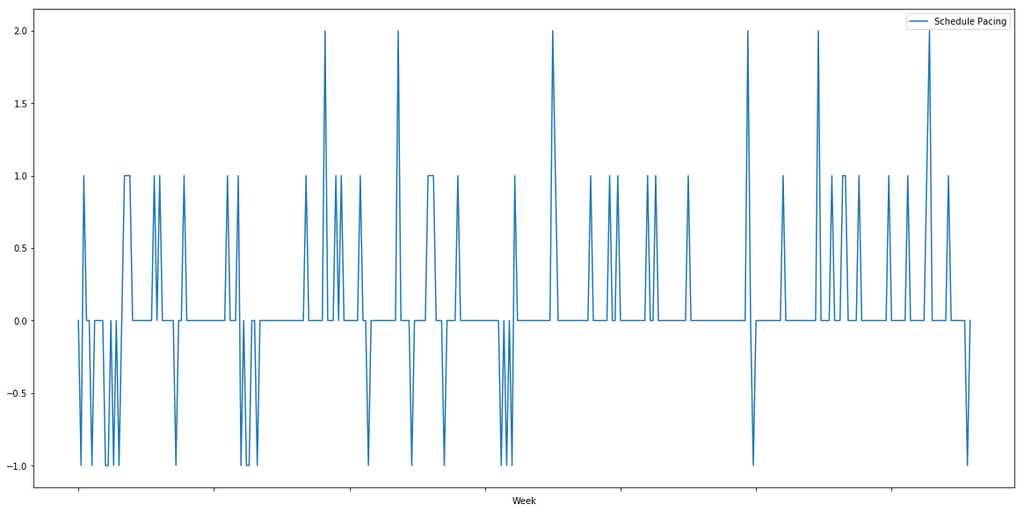

```python
ax = df_NY.plot.line(x='Week', y='Schedule Pacing', figsize=(20,10))
```

## How many people who felt like they were behind, kept feeling like they were behind? Did anyone feel like the learning was too slow at one point feel that learning was too fast at another?

```python
## Take all the people who said that the material was too slow and see if any of them also said that the material was too fast
```

```python
df_NY_Slow = df_NY[(df_NY['Schedule Pacing'] == -1)]
```

```python
df_NY_Slow
```

|  | ID | Location | Track | Week | Rating (Num) | Schedule Pacing |
| --- | --- | --- | --- | --- | --- | --- |
| 17 | 336 | New York City | Apps | Week 1 | 5 | -1.0 |
| 82 | 343 | New York City | Apps | Week 1 | 7 | -1.0 |
| 187 | 306 | New York City | Apps | Week 1 | 8 | -1.0 |
| 195 | 330 | New York City | Apps | Week 1 | 8 | -1.0 |
| 197 | 332 | New York City | Apps | Week 1 | 8 | -1.0 |
| 199 | 334 | New York City | Games | Week 1 | 8 | -1.0 |
| 373 | 492 | New York City | Apps | Week 1 | 9 | -1.0 |
| 557 | 588 | New York City | Apps | Week 2 | 9 | -1.0 |
| 559 | 590 | New York City | Apps | Week 2 | 8 | -1.0 |
| 560 | 591 | New York City | Apps | Week 2 | 9 | -1.0 |
| 563 | 594 | New York City | Apps | Week 2 | 9 | -1.0 |
| 720 | 758 | New York City | Games | Week 2 | 8 | -1.0 |
| 800 | 838 | New York City | Apps | Week 3 | 9 | -1.0 |
| 815 | 853 | New York City | Apps | Week 3 | 6 | -1.0 |
| 952 | 995 | New York City | Apps | Week 3 | 5 | -1.0 |
| 1010 | 1053 | New York City | Apps | Week 4 | 10 | -1.0 |
| 1012 | 1055 | New York City | Games | Week 4 | 9 | -1.0 |
| 1339 | 1386 | New York City | Apps | Week 5 | 6 | -1.0 |
| 1451 | 1498 | New York City | Apps, Explorer | Week 7 | 1 | -1.0 |

```python
df_NY_Fast = df_NY[(df_NY['Schedule Pacing'] == (1 or 2))]
```

```python
df_NY_Fast
```

|  | ID | Location | Track | Week | Rating (Num) | Schedule Pacing |
| --- | --- | --- | --- | --- | --- | --- |
| 34 | 347 | New York City | Games | Week 1 | 6 | 1.0 |
| 201 | 341 | New York City | Apps | Week 1 | 8 | 1.0 |
| 202 | 342 | New York City | Games | Week 1 | 8 | 1.0 |
| 203 | 345 | New York City | Games | Week 1 | 8 | 1.0 |
| 251 | 498 | New York City | Apps | Week 1 | 8 | 1.0 |
| 253 | 501 | New York City | Apps, Explorer | Week 1 | 8 | 1.0 |
| 436 | 338 | New York City | Apps | Week 1 | 10 | 1.0 |
| 551 | 582 | New York City | Apps | Week 2 | 7 | 1.0 |
| 555 | 586 | New York City | Apps | Week 2 | 8 | 1.0 |
| 583 | 614 | New York City | Apps | Week 2 | 10 | 1.0 |
| 688 | 722 | New York City | Apps | Week 2 | 8 | 1.0 |
| 698 | 733 | New York City | Apps | Week 2 | 8 | 1.0 |
| 717 | 755 | New York City | Apps | Week 3 | 10 | 1.0 |
| 806 | 844 | New York City | Apps | Week 3 | 9 | 1.0 |
| 807 | 845 | New York City | Apps | Week 3 | 3 | 1.0 |
| 809 | 847 | New York City | Apps | Week 3 | 9 | 1.0 |
| 820 | 858 | New York City | Apps | Week 3 | 8 | 1.0 |
| 1013 | 1056 | New York City | Apps | Week 4 | 4 | 1.0 |
| 1028 | 1071 | New York City | Apps | Week 4 | 9 | 1.0 |
| 1132 | 1177 | New York City | Apps, Explorer | Week 4 | 5 | 1.0 |
| 1139 | 1184 | New York City | Apps, Explorer | Week 4 | 8 | 1.0 |
| 1144 | 1189 | New York City | Apps | Week 4 | 6 | 1.0 |
| 1215 | 1261 | New York City | Apps | Week 5 | 0 | 1.0 |
| 1218 | 1264 | New York City | Apps, Explorer | Week 5 | 8 | 1.0 |
| 1230 | 1276 | New York City | Apps, Explorer | Week 5 | 6 | 1.0 |
| 1363 | 1410 | New York City | Apps | Week 6 | 7 | 1.0 |
| 1381 | 1428 | New York City | Apps | Week 6 | 8 | 1.0 |
| 1385 | 1432 | New York City | Apps | Week 6 | 8 | 1.0 |
| 1386 | 1433 | New York City | Apps, Explorer | Week 6 | 7 | 1.0 |
| 1391 | 1438 | New York City | Apps | Week 6 | 7 | 1.0 |
| 1422 | 1469 | New York City | Games | Week 7 | 10 | 1.0 |
| 1429 | 1476 | New York City | Apps | Week 7 | 8 | 1.0 |
| 1436 | 1483 | New York City | Apps | Week 7 | 7 | 1.0 |
| 1444 | 1491 | New York City | Games | Week 7 | 9 | 1.0 |

```python
df_NY.where(df_NY_Slow['ID'] == df_NY_Fast['ID'])
```

```
---------------------------------------------------------------------------
ValueError                                Traceback (most recent call last)
<ipython-input-75-80ee6a33d4d3> in <module>
----> 1 df_NY.where(df_NY_Slow['ID'] == df_NY_Fast['ID'])

~/anaconda3/lib/python3.7/site-packages/pandas/core/ops.py in wrapper(self, other, axis)
   1188
   1189         elif isinstance(other, ABCSeries) and not self._indexed_same(other):
-> 1190             raise ValueError("Can only compare identically-labeled "
   1191                              "Series objects")
   1192

ValueError: Can only compare identically-labeled Series objects
```

```python
df_NY_Slow['ID'][1]
```

[output not shown]

```python
df_NY_Fast.reset_index(inplace=True)
```

```python
del df_NY_Fast['index']
```

```python
df_NY_Slow.reset_index(inplace=True)
```

```python
del df_NY_Slow['index']
```

```python
x = list(df_NY_Fast['ID'].values)
```

```python
df_both = df_NY_Slow['ID'].map(lambda row: row if row in df_NY_Fast['ID'] else None)
```

```python
df_both
```

```
0     None
1     None
2     None
3     None
4     None
5     None
6     None
7     None
8     None
9     None
10    None
11    None
12    None
13    None
14    None
15    None
16    None
17    None
18    None
Name: ID, dtype: object
```

## Next, are there any trends in each of the tracks in New York City?

```python
df_NY_Apps = df_NY[(df_NY['Track'] == "Apps")]
```

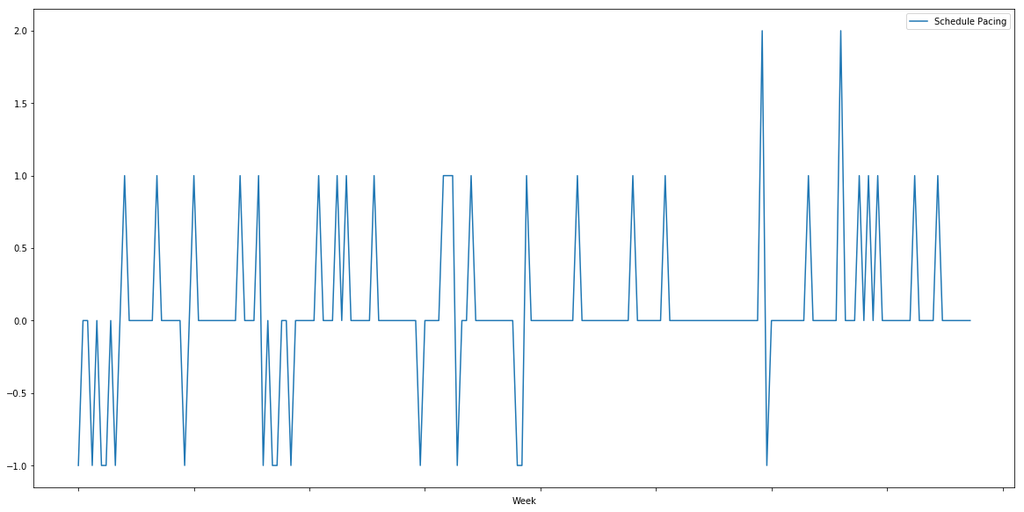

```python
ax = df_NY_Apps.plot.line(x='Week', y='Schedule Pacing', figsize=(20,10))
```

```python
df_NY_Apps_Explorer = df_NY[(df_NY['Track'] == "Apps, Explorer")]
```

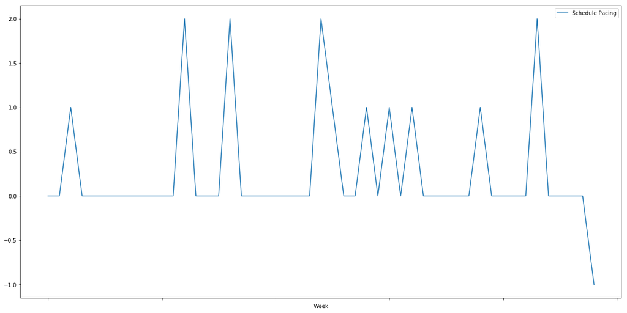

```python
ax = df_NY_Apps_Explorer.plot.line(x='Week', y='Schedule Pacing', figsize=(20,10))
```

```python
df_NY_Games = df_NY[(df_NY['Track'] == "Games")]
```

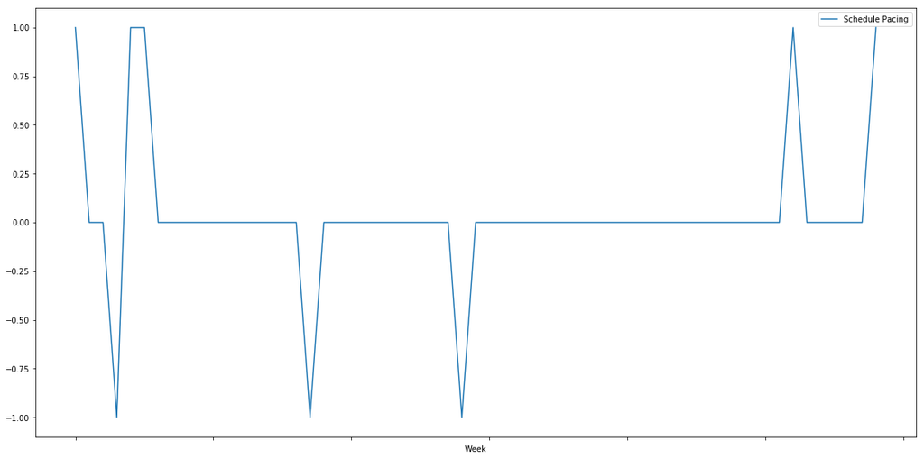

```python
ax = df_NY_Games.plot.line(x='Week', y='Schedule Pacing', figsize=(20,10))
```

## For the most part, it seems like the Games participants were happy with the pacing of the course (with exception of feeling left behind or doing too many repetitive tasks in the beginning)

```python
df_NY_Games_Explorer = df_NY[(df_NY['Track'] == "Games, Explorer")]
```

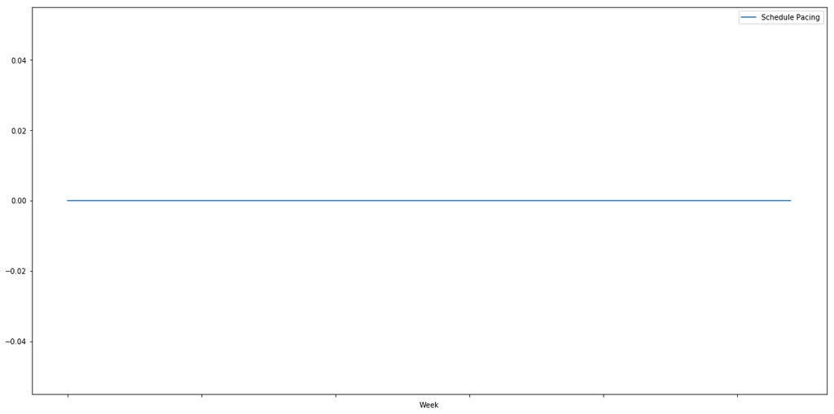

```python
ax = df_NY_Games_Explorer.plot.line(x='Week', y='Schedule Pacing', figsize=(20,10))
```

```python
df_NY_Games_Explorer
```

|  | ID | Location | Track | Week | Rating (Num) | Schedule Pacing |
| --- | --- | --- | --- | --- | --- | --- |
| 198 | 333 | New York City | Games, Explorer | Week 1 | 8 | 0.0 |
| 211 | 366 | New York City | Games, Explorer | Week 1 | 8 | 0.0 |
| 375 | 500 | New York City | Games, Explorer | Week 1 | 9 | 0.0 |
| 507 | 535 | New York City | Games, Explorer | Week 1 | 10 | 0.0 |
| 564 | 595 | New York City | Games, Explorer | Week 2 | 9 | 0.0 |
| 574 | 605 | New York City | Games, Explorer | Week 2 | 10 | 0.0 |
| 585 | 616 | New York City | Games, Explorer | Week 2 | 10 | 0.0 |
| 589 | 620 | New York City | Games, Explorer | Week 2 | 7 | 0.0 |
| 790 | 828 | New York City | Games, Explorer | Week 3 | 9 | 0.0 |
| 817 | 855 | New York City | Games, Explorer | Week 3 | 9 | 0.0 |
| 827 | 865 | New York City | Games, Explorer | Week 3 | 10 | 0.0 |
| 828 | 866 | New York City | Games, Explorer | Week 3 | 7 | 0.0 |
| 1033 | 1076 | New York City | Games, Explorer | Week 4 | 8 | 0.0 |
| 1035 | 1078 | New York City | Games, Explorer | Week 4 | 10 | 0.0 |
| 1036 | 1079 | New York City | Games, Explorer | Week 4 | 10 | 0.0 |
| 1046 | 1089 | New York City | Games, Explorer | Week 4 | 9 | 0.0 |
| 1217 | 1263 | New York City | Games, Explorer | Week 5 | 10 | 0.0 |
| 1219 | 1265 | New York City | Games, Explorer | Week 5 | 10 | 0.0 |
| 1238 | 1284 | New York City | Games, Explorer | Week 5 | 8 | 0.0 |
| 1241 | 1287 | New York City | Games, Explorer | Week 5 | 10 | 0.0 |
| 1366 | 1413 | New York City | Games, Explorer | Week 6 | 10 | 0.0 |
| 1383 | 1430 | New York City | Games, Explorer | Week 6 | 10 | 0.0 |
| 1388 | 1435 | New York City | Games, Explorer | Week 6 | 7 | 0.0 |
| 1392 | 1439 | New York City | Games, Explorer | Week 6 | 10 | 0.0 |
| 1421 | 1468 | New York City | Games, Explorer | Week 7 | 10 | 0.0 |
| 1426 | 1473 | New York City | Games, Explorer | Week 7 | 10 | 0.0 |
| 1441 | 1488 | New York City | Games, Explorer | Week 7 | 7 | 0.0 |
| 1447 | 1494 | New York City | Games, Explorer | Week 7 | 10 | 0.0 |

## We have extremely satisfied Games Explorers.

## Future Explorations:

Are the IDs actually representative of who filled out the survey? If so, this information can be used to track who filled out the survey and when.

Also, how does this correlate with NPS?

```python
df_test_ID = df_NY[(df_NY['ID'] == 366)]
```

```python
df_test_ID
```

|  | ID | Location | Track | Week | Rating (Num) | Schedule Pacing |
| --- | --- | --- | --- | --- | --- | --- |
| 211 | 366 | New York City | Games, Explorer | Week 1 | 8 | 0.0 |

## This nullifies the previous find that no one who thought the class was too fast also thought it was too slow.